# hw_1

Jake Greenberg

3/25/2021

```r
library(tidyverse)         # for reading in data, graphing, and cleaning
library(tidymodels)        # for modeling ... tidily
library(glmnet)            # for regularized regression, including LASSO
library(naniar)            # for examining missing values (NAs)
library(lubridate)         # for date manipulation
library(moderndive)        # for King County housing data
library(vip)               # for variable importance plots
library(rmarkdown)         # for paged tables
library(rsample)
library(recipes)
```

```r
theme_set(theme_minimal()) # Lisa's favorite theme
```

# Setting up Git and GitHub in RStudio

**Read the Quick Intro section of the Using git and GitHub in R Studio set of Course Materials. Set up Git and GitHub and create a GitHub repo and associated R Project (done for you when you clone the repo) for this homework assignment. Put this file into the project. You should always open the R Project (.Rproj) file when you work with any of the files in the project.**

##Task: Below, post a link to your GitHub repository:

### GitHub repository (ADSIR acronym is just the abbreviation for the course):

https://github.com/jgreenb4/jake_greenberg_adsir_hw_1

# **Website Name: https://jakegreenberg.netlify.app/**

## **Reflection**

After listening to “Building a Career in Data Science, Chapter 4: Building a Portfolio”, I think that the discussion was extremely insightful with exhibiting the usefulness of having a personal website. I know from my experience with applying to “analyst/data scientist” type roles over the past year that it is imperative to have easily showcased work to separate yourself from the compeition, and so having an organized website that can clearly and efficiently articulate what you are capable of doing could serve as a logical way to craft your portfolio and enable its accessibility to the public.

# Machine Learning review and intro to tidymodels

**Read through and follow along with the Machine Learning review with an intro to the tidymodels package posted on the Course Materials page.**

## Tasks:

```
Read about the hotel booking data, hotels, on the Tidy Tuesday page it came from. There is also a link to an article from the original authors. The outcome we will be predicting is called is_canceled.

Without doing any analysis, what are some variables you think might be predictive and why?
_ What are some problems that might exist with the data? You might think about how it was collected and who did the collecting.
If we construct a model, what type of conclusions will be able to draw from it?
```

## 1.

After browsing the table of variables in the Data Dictionary, I would expect for the most important predictive variables of is_canceled to be lead_time, arrival_date_year (especially if 2020 is included in the data frame), arrival_date_week_number, number of children, number of babies, market_segment, previous_cancellations, is_repeated_guest, deposit_type, and total_of_special_requests.

I think that some of the problems that may exist with the data could be privacy concerns with the individual consumer-level detail of each observation, such as revealing the total number of special requests and previous cancellations for a customer. Because the authors use the hotel’s databases to construct this dataset, I would want more information on hotel guests consenting to have their information publicly included in this data. Another potential issue with this data could be the lack of a unique observation id variable, which could make identical observations that are duplicates indistinguishable from those that are not.

Also, I would think that cost-measuring variables such as price charged and market price for a booking could be influencing factors in the probability of a consumer canceling a booking.

I believe that the model we will construct will enable us to draw conclusions both on the micro-level, as an optimized model should enable us to make meaningful predictions/classifications of the probability of an individual booking ultimately being canceled, and macro-level, as the optimized model should also reveal which variables are the primary determinants of cancelation risk.

## 2.

```r
# read in the data
hotels <- readr::read_csv('https://raw.githubusercontent.com/rfordatascience/tidytuesday/master/data/2020/2020-02-11/hotels.csv')
```

**Create some exploratory plots or table summaries of the data, concentrating most on relationships with the response variable. Keep in mind the response variable is numeric, 0 or 1. You may want to make it categorical (you also may not). Be sure to also examine missing values or other interesting values.**

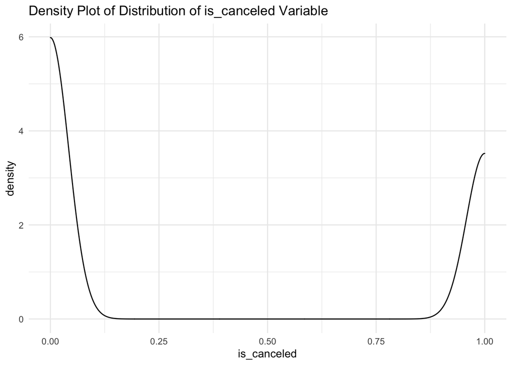

```r
hotels %>%
  ggplot(aes(x = is_canceled)) +
  geom_density() +
  ggtitle("Density Plot of Distribution of is_canceled Variable")
```

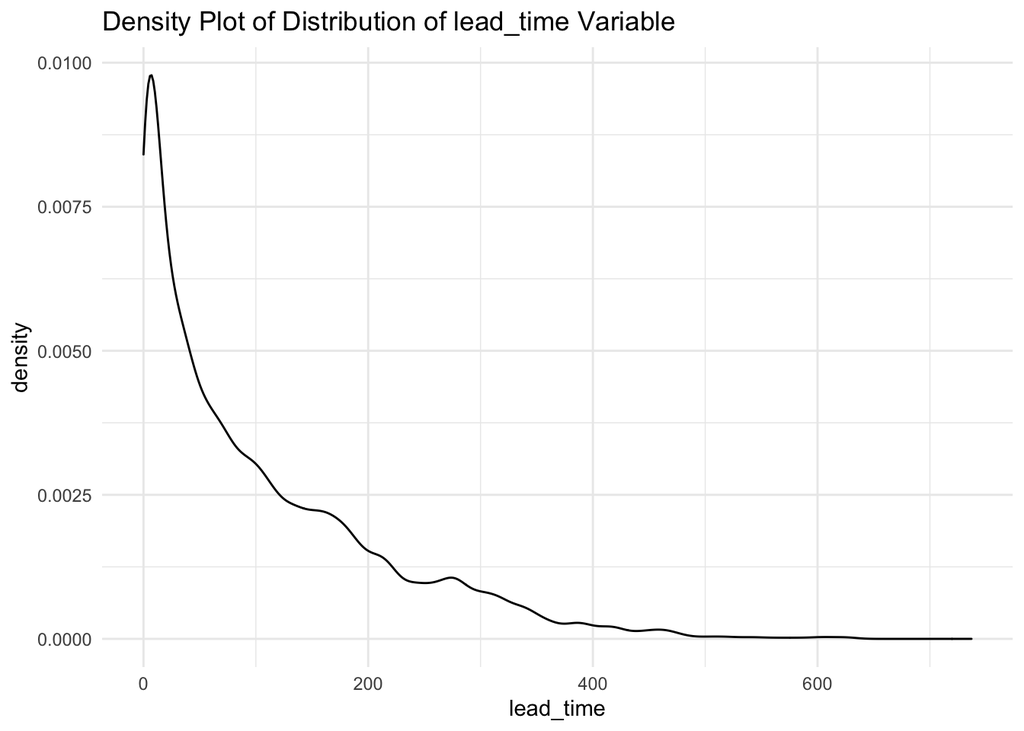

```r
hotels %>%
  ggplot(aes(x = lead_time)) +
  geom_density() +
  ggtitle("Density Plot of Distribution of lead_time Variable")
```

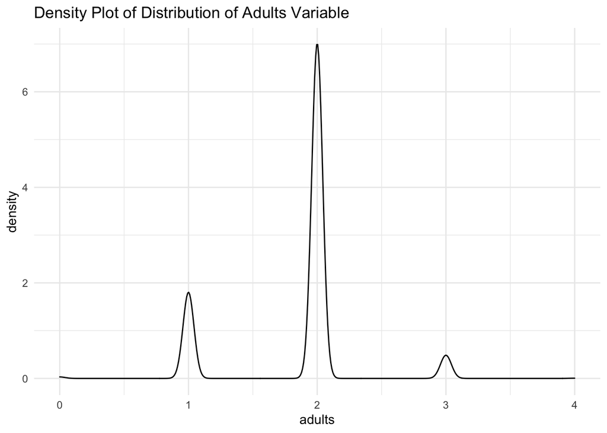

```r
hotels %>%
  group_by(adults) %>%
  filter(n() > 5) %>%
  ggplot(aes(x = adults)) +
  geom_density() +
  ggtitle("Density Plot of Distribution of Adults Variable")
```

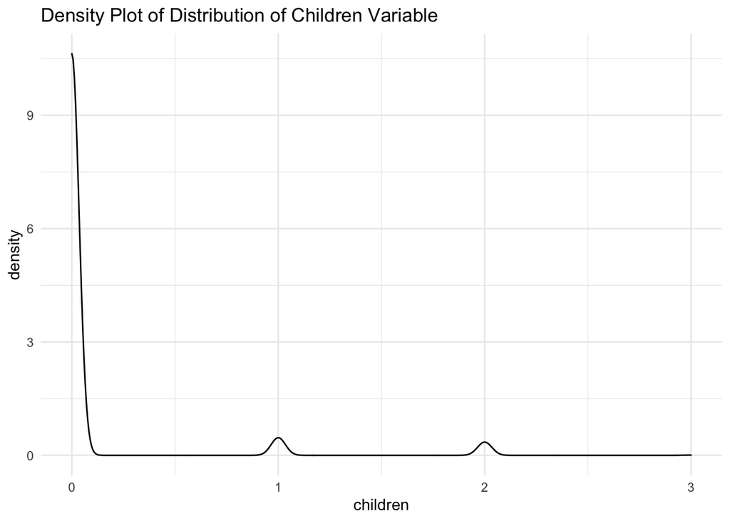

```r
hotels %>%
  group_by(children) %>%
  filter(n() > 5) %>%
  ggplot(aes(x = children)) +
  geom_density() +
  ggtitle("Density Plot of Distribution of Children Variable")
```

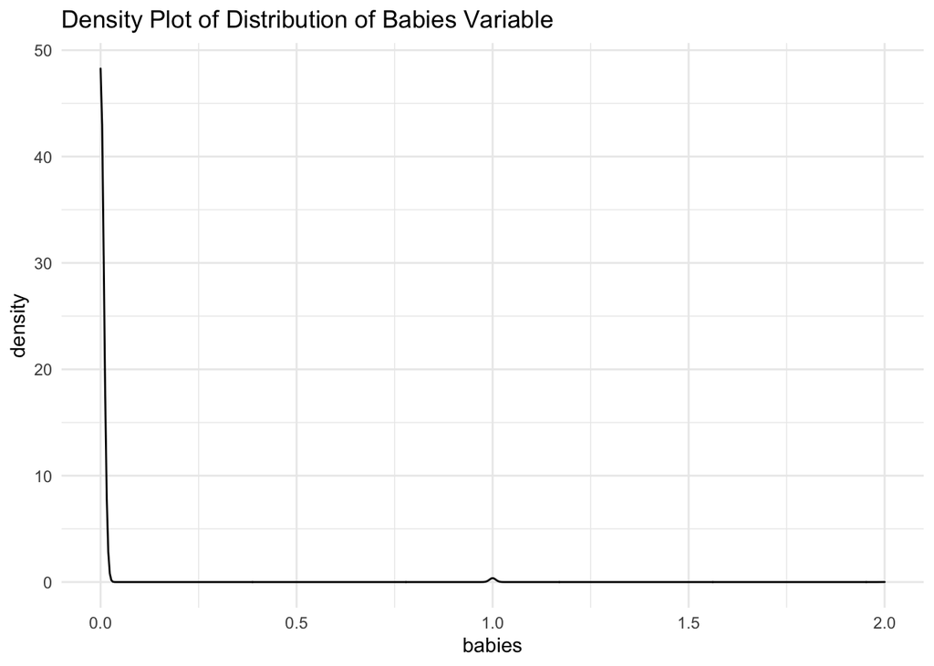

```r
hotels %>%
  group_by(babies) %>%
  filter(n() > 5) %>%
  ggplot(aes(x = babies)) +
  geom_density() +
  ggtitle("Density Plot of Distribution of Babies Variable")
```

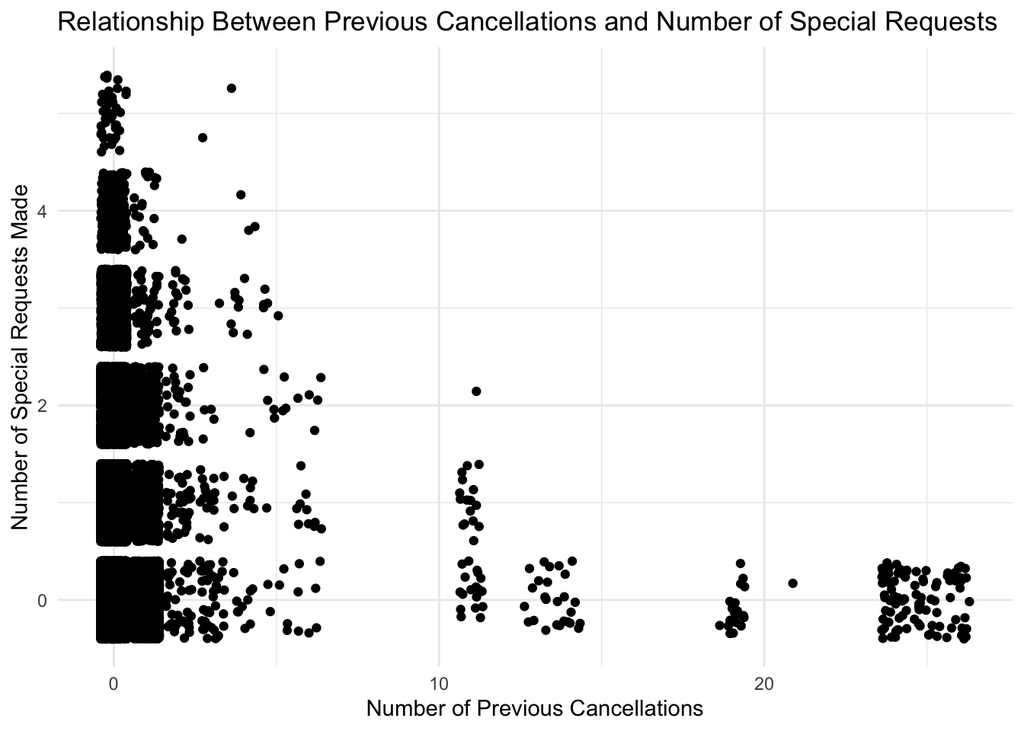

```r
hotels %>%
  ggplot(aes(x = previous_cancellations, y = total_of_special_requests)) +
  geom_jitter() +
  ggtitle("Relationship Between Previous Cancellations and Number of Special Requests") +
  labs(x = "Number of Previous Cancellations", y = "Number of Special Requests Made")
```

```r
#hotels %>%
  #group_by(hotel, arrival_date_week_number) %>%
  #mutate(`Total Bookings` = n()) %>%
  #filter(is_canceled == 1) %>%
  #mutate(`Cancellations` = n(), `Cancellation Percentage` = `Cancellations`/`Total Bookings`) %>%
  #distinct(hotel, `Cancellation Percentage`) %>%
  #rename(Hotel = hotel) %>%
  #ggplot(aes(x = arrival_date_week_number, y = `Cancellation Percentage`, color = Hotel)) + geom_line() +
  #ggtitle("Cancellation Rate by Arrival Date Week of the Year and Hotel") +
  #labs(x = "Arrival Date Number Week of the Year", y = "Cancellation Percentage (%)") +
  #theme(panel.border = element_rect(fill = NA, size = 1))
```

```r
#hotels %>%
  #group_by(hotel, arrival_date_year) %>%
  #mutate(`Total Bookings` = n(), arrival_date_year = as.factor(arrival_date_year)) %>%
  #filter(is_canceled == 1) %>%
  #mutate(`Cancellations` = n(), `Cancellation Percentage` = `Cancellations`/`Total Bookings`) %>%
  #distinct(hotel, `Cancellation Percentage`) %>%
  #rename(Hotel = hotel, `Arrival Date Year` = arrival_date_year) %>%
  #ggplot(aes(x = `Arrival Date Year`, y = `Cancellation Percentage`, fill = `Arrival Date Year`)) + geom_bar(stat = "identity") +
  #facet_grid(~Hotel) +
  #ggtitle("Cancellation Rate by Arrival Date Year and Hotel") +
  #labs(x = "Arrival Date Year", y = "Cancellation Percentage (%)") +
  #theme(panel.border = element_rect(color = "black", fill = NA, size = 1))
```

```r
sum(is.na(hotels)) # there are 4 missing values in this dataset
```

```
## [1] 4
```

```r
which(is.na(hotels)) # locations of the missing values
```

```
## [1] 1234501 1234568 1234580 1235061
```

```r
summary(hotels) # summary of each of the variables in the dataset and their ranges; there seem to be some abnormally large parties with odd breakdowns, such as a couple with more than 8 babies and just two adults.
```

```
##     hotel            is_canceled       lead_time   arrival_date_year
##  Length:119390      Min.   :0.0000   Min.   :  0   Min.   :2015
##  Class :character   1st Qu.:0.0000   1st Qu.: 18   1st Qu.:2016
##  Mode  :character   Median :0.0000   Median : 69   Median :2016
##                     Mean   :0.3704   Mean   :104   Mean   :2016
##                     3rd Qu.:1.0000   3rd Qu.:160   3rd Qu.:2017
##                     Max.   :1.0000   Max.   :737   Max.   :2017
##
##  arrival_date_month arrival_date_week_number arrival_date_day_of_month
##  Length:119390      Min.   : 1.00            Min.   : 1.0
##  Class :character   1st Qu.:16.00            1st Qu.: 8.0
##  Mode  :character   Median :28.00            Median :16.0
##                     Mean   :27.17            Mean   :15.8
##                     3rd Qu.:38.00            3rd Qu.:23.0
##                     Max.   :53.00            Max.   :31.0
##
##  stays_in_weekend_nights stays_in_week_nights     adults
##  Min.   : 0.0000         Min.   : 0.0         Min.   : 0.000
##  1st Qu.: 0.0000         1st Qu.: 1.0         1st Qu.: 2.000
##  Median : 1.0000         Median : 2.0         Median : 2.000
##  Mean   : 0.9276         Mean   : 2.5         Mean   : 1.856
##  3rd Qu.: 2.0000         3rd Qu.: 3.0         3rd Qu.: 2.000
##  Max.   :19.0000         Max.   :50.0         Max.   :55.000
##
##     children           babies              meal             country
##  Min.   : 0.0000   Min.   : 0.000000   Length:119390      Length:119390
##  1st Qu.: 0.0000   1st Qu.: 0.000000   Class :character   Class :character
##  Median : 0.0000   Median : 0.000000   Mode  :character   Mode  :character
##  Mean   : 0.1039   Mean   : 0.007949
##  3rd Qu.: 0.0000   3rd Qu.: 0.000000
##  Max.   :10.0000   Max.   :10.000000
##  NA's   :4
##  market_segment     distribution_channel is_repeated_guest
##  Length:119390      Length:119390        Min.   :0.00000
##  Class :character   Class :character     1st Qu.:0.00000
##  Mode  :character   Mode  :character     Median :0.00000
##                                          Mean   :0.03191
##                                          3rd Qu.:0.00000
##                                          Max.   :1.00000
##
```

[output cut: 25 more lines]

```
##  Min.   :0.00000             Min.   :0.0000            Length:119390
##  1st Qu.:0.00000             1st Qu.:0.0000            Class :character
##  Median :0.00000             Median :0.0000            Mode  :character
##  Mean   :0.06252             Mean   :0.5714
##  3rd Qu.:0.00000             3rd Qu.:1.0000
##  Max.   :8.00000             Max.   :5.0000
##
##  reservation_status_date
##  Min.   :2014-10-17
##  1st Qu.:2016-02-01
##  Median :2016-08-07
##  Mean   :2016-07-30
##  3rd Qu.:2017-02-08
##  Max.   :2017-09-14
##
```

# 3

```r
hotels_mod <- hotels %>%
  mutate(is_canceled = as.factor(is_canceled)) %>%
  mutate(across(where(is.character), as.factor)) %>%
  select(-arrival_date_year,
         -reservation_status,
         -reservation_status_date) %>%
  add_n_miss() %>%
  filter(n_miss_all == 0) %>%
  select(-n_miss_all)

set.seed(494)
```

**First, we will do a couple things to get the data ready, including making the outcome a factor (needs to be that way for logistic regression), removing the year variable and some reservation status variables, and removing missing values (not NULLs but true missing values). Split the data into a training and test set, stratifying on the outcome variable, is_canceled. Since we have a lot of data, we’re going to split the data 50/50 between training and test. I have already set.seed() for you. Be sure to use hotels_mod in the splitting.**

```r
set.seed(494)
hotels_split <- initial_split(hotels_mod, prop = .5, strata = "is_canceled")
hotels_train <- training(hotels_split)
hotels_test <- testing(hotels_split)
```

# 4

**In this next step, we are going to do the pre-processing. Usually, I won’t tell you exactly what to do here, but for your first exercise, I’ll tell you the steps.**

**Set up the recipe with is_canceled as the outcome and all other variables as predictors (HINT: ~.).** **Use a step_XXX() function or functions (I think there are other ways to do this, but I found step_mutate_at() easiest) to create some indicator variables for the following variables:children,babies, andprevious_cancellations`. So, the new variable should be a 1 if the original is more than 0 and 0 otherwise. Make sure you do this in a way that accounts for values that may be larger than any we see in the dataset.** **For the agent and company variables, make new indicator variables that are 1 if they have a value of NULL and 0 otherwise.** **Use fct_lump_n() to lump together countries that aren’t in the top 5 most occurring.** **If you used new names for some of the new variables you created, then remove any variables that are no longer needed.** **Use step_normalize() to center and scale all the non-categorical predictor variables. (Do this BEFORE creating dummy variables. When I tried to do it after, I ran into an error - I’m still investigating why.)** **Create dummy variables for all factors/categorical predictor variables (make sure you have -all_outcomes() in this part!!).** **Use the prep() and juice() functions to apply the steps to the training data just to check that everything went as planned.**

```r
hotels_recipe <- recipe(is_canceled ~ ., data = hotels_train) %>%
  step_mutate_at(children, babies, previous_cancellations, fn = ~as.factor((. > 0))) %>%
  step_mutate_at(agent, company, fn = ~as.factor(. == "NULL")) %>%
  step_mutate(country = fct_lump_n(country, 5)) %>%
  step_normalize(all_numeric()) %>%
  step_dummy(all_nominal(), -all_outcomes())


hotels_recipe %>%
  prep(hotels_train) %>%
  juice()
```

```
## # A tibble: 59,693 x 76
##    lead_time arrival_date_we… arrival_date_da… stays_in_weeken… stays_in_week_n…
##        <dbl>            <dbl>            <dbl>            <dbl>            <dbl>
##  1     5.94           -0.0113            -1.68          -0.933            -1.32
##  2    -0.909          -0.0113            -1.68          -0.933            -0.794
##  3    -0.844          -0.0113            -1.68          -0.933            -0.266
##  4    -0.178          -0.0113            -1.68          -0.933             0.262
##  5    -0.272          -0.0113            -1.68          -0.933             0.262
##  6    -0.759          -0.0113            -1.68          -0.933             0.790
##  7    -0.647          -0.0113            -1.68          -0.933             0.790
##  8    -0.975          -0.0113            -1.68          -0.933            -0.794
##  9    -0.909          -0.0113            -1.68          -0.933             0.790
## 10    -0.628          -0.0113            -1.68           0.0713            0.790
## # … with 59,683 more rows, and 71 more variables: adults <dbl>,
## #   is_repeated_guest <dbl>, previous_bookings_not_canceled <dbl>,
## #   booking_changes <dbl>, days_in_waiting_list <dbl>, adr <dbl>,
## #   required_car_parking_spaces <dbl>, total_of_special_requests <dbl>,
## #   is_canceled <fct>, hotel_Resort.Hotel <dbl>,
## #   arrival_date_month_August <dbl>, arrival_date_month_December <dbl>,
## #   arrival_date_month_February <dbl>, arrival_date_month_January <dbl>,
## #   arrival_date_month_July <dbl>, arrival_date_month_June <dbl>,
## #   arrival_date_month_March <dbl>, arrival_date_month_May <dbl>,
## #   arrival_date_month_November <dbl>, arrival_date_month_October <dbl>,
## #   arrival_date_month_September <dbl>, children_TRUE. <dbl>,
## #   babies_TRUE. <dbl>, meal_FB <dbl>, meal_HB <dbl>, meal_SC <dbl>,
## #   meal_Undefined <dbl>, country_ESP <dbl>, country_FRA <dbl>,
## #   country_GBR <dbl>, country_PRT <dbl>, country_Other <dbl>,
## #   market_segment_Complementary <dbl>, market_segment_Corporate <dbl>,
## #   market_segment_Direct <dbl>, market_segment_Groups <dbl>,
## #   market_segment_Offline.TA.TO <dbl>, market_segment_Online.TA <dbl>,
## #   market_segment_Undefined <dbl>, distribution_channel_Direct <dbl>,
## #   distribution_channel_GDS <dbl>, distribution_channel_TA.TO <dbl>,
## #   distribution_channel_Undefined <dbl>, previous_cancellations_TRUE. <dbl>,
## #   reserved_room_type_B <dbl>, reserved_room_type_C <dbl>,
## #   reserved_room_type_D <dbl>, reserved_room_type_E <dbl>,
## #   reserved_room_type_F <dbl>, reserved_room_type_G <dbl>,
## #   reserved_room_type_H <dbl>, reserved_room_type_L <dbl>,
## #   reserved_room_type_P <dbl>, assigned_room_type_B <dbl>,
## #   assigned_room_type_C <dbl>, assigned_room_type_D <dbl>,
## #   assigned_room_type_E <dbl>, assigned_room_type_F <dbl>,
## #   assigned_room_type_G <dbl>, assigned_room_type_H <dbl>,
## #   assigned_room_type_I <dbl>, assigned_room_type_K <dbl>,
## #   assigned_room_type_L <dbl>, assigned_room_type_P <dbl>,
## #   deposit_type_Non.Refund <dbl>, deposit_type_Refundable <dbl>,
## #   agent_TRUE. <dbl>, company_TRUE. <dbl>, customer_type_Group <dbl>,
## #   customer_type_Transient <dbl>, customer_type_Transient.Party <dbl>
```

# 5

**In this step we will set up a LASSO model and workflow.**

**In general, why would we want to use LASSO instead of regular logistic regression? (HINT: think about what happens to the coefficients).**

**Define the model type, set the engine, set the penalty argument to tune() as a placeholder, and set the mode. Create a workflow with the recipe and model.**

In general, I believe that a LASSO model works better than a regular logistic regression at predicting the probability of a given booking resulting in a cancellation because it will adjust the weights of the coefficients for each variable according to its importance as a predictor (due to the regularization parameter). As a result, if a variable is included in the regression but carries little importance as a predictor of is_canceled, then that coefficient’s weight in the regression will be reduced towards 0.

```r
hotels_lasso_mod <-
  # Define a linear regression model
  logistic_reg() %>%
  # Set the engine to "lm" (lm() function is used to fit model)
  set_engine("glmnet") %>%
  set_args(penalty = tune()) %>%
  # Not necessary here, but good to remember for other models
  set_mode("classification")



hotels_lasso_wf <-
  # Set up the workflow
  workflow() %>%
  # Add the recipe
  add_recipe(hotels_recipe) %>%
  # Add the modeling
  add_model(hotels_lasso_mod)

hotels_lasso_wf
```

```
## ══ Workflow ════════════════════════════════════════════════════════════════════
## Preprocessor: Recipe
## Model: logistic_reg()
##
## ── Preprocessor ────────────────────────────────────────────────────────────────
## 5 Recipe Steps
##
## ● step_mutate_at()
## ● step_mutate_at()
## ● step_mutate()
## ● step_normalize()
## ● step_dummy()
##
## ── Model ───────────────────────────────────────────────────────────────────────
## Logistic Regression Model Specification (classification)
##
## Main Arguments:
##   penalty = tune()
##
## Computational engine: glmnet
```

# 6

**In this step, we’ll tune the model and fit the model using the best tuning parameter to the entire training dataset.**

**Create a 5-fold cross-validation sample. We’ll use this later. I have set the seed for you.** **Use the grid_regular() function to create a grid of 10 potential penalty parameters (we’re keeping this sort of small because the dataset is pretty large). Use that with the 5-fold cv data to tune the model.** **Use the tune_grid() function to fit the models with different tuning parameters to the different cross-validation sets.** **Use the collect_metrics() function to collect all the metrics from the previous step and create a plot with the accuracy on the y-axis and the penalty term on the x-axis. Put the x-axis on the log scale.** **Use the select_best() function to find the best tuning parameter, fit the model using that tuning parameter to the entire training set (HINT: finalize_workflow() and fit()), and display the model results using pull_workflow_fit() and tidy(). Are there some variables with coefficients of 0?**

```r
set.seed(494) # for reproducibility
hotels_cv <- vfold_cv(hotels_train, v = 5)
```

```r
penalty_grid <- grid_regular(penalty(),
                             levels = 10)
penalty_grid
```

```
## # A tibble: 10 x 1
##          penalty
##            <dbl>
##  1 0.0000000001
##  2 0.00000000129
##  3 0.0000000167
##  4 0.000000215
##  5 0.00000278
##  6 0.0000359
##  7 0.000464
##  8 0.00599
##  9 0.0774
## 10 1
```

```r
hotels_lasso_tune <-
  hotels_lasso_wf %>%
  tune_grid(
    resamples = hotels_cv,
    grid = penalty_grid
    )


hotels_lasso_tune
```

```
## # Tuning results
## # 5-fold cross-validation
## # A tibble: 5 x 4
##   splits                id    .metrics          .notes
##   <list>                <chr> <list>            <list>
## 1 <split [47754/11939]> Fold1 <tibble [20 × 5]> <tibble [0 × 1]>
## 2 <split [47754/11939]> Fold2 <tibble [20 × 5]> <tibble [0 × 1]>
## 3 <split [47754/11939]> Fold3 <tibble [20 × 5]> <tibble [0 × 1]>
## 4 <split [47755/11938]> Fold4 <tibble [20 × 5]> <tibble [0 × 1]>
## 5 <split [47755/11938]> Fold5 <tibble [20 × 5]> <tibble [0 × 1]>
```

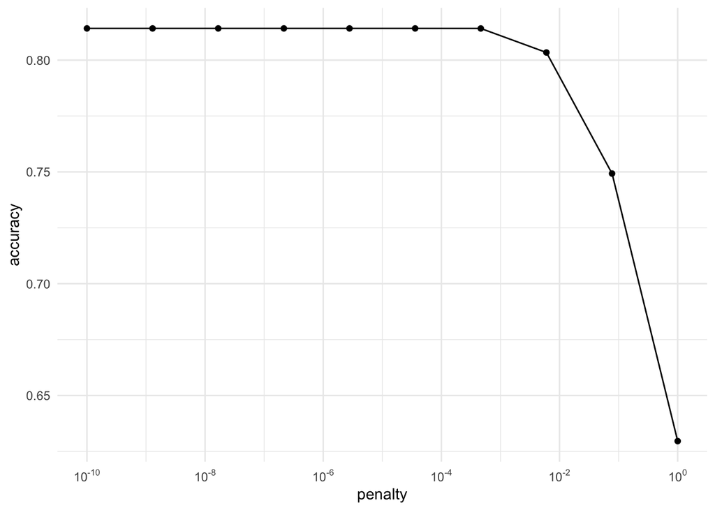

```r
hotels_lasso_tune %>%
  collect_metrics() %>%
  filter(.metric == "accuracy") %>%
  ggplot(aes(x = penalty, y = mean)) +
  geom_point() +
  geom_line() +
  scale_x_log10(
   breaks = scales::trans_breaks("log10", function(x) 10^x),
   labels = scales::trans_format("log10",scales::math_format(10^.x))) +
  labs(x = "penalty", y = "accuracy")
```

```r
hotels_lasso_tune %>%
  show_best(metric = "accuracy")
```

```
## # A tibble: 5 x 7
##         penalty .metric  .estimator  mean     n  std_err .config
##           <dbl> <chr>    <chr>      <dbl> <int>    <dbl> <fct>
## 1 0.0000000001  accuracy binary     0.814     5 0.000923 Preprocessor1_Model01
## 2 0.00000000129 accuracy binary     0.814     5 0.000923 Preprocessor1_Model02
## 3 0.0000000167  accuracy binary     0.814     5 0.000923 Preprocessor1_Model03
## 4 0.000000215   accuracy binary     0.814     5 0.000923 Preprocessor1_Model04
## 5 0.00000278    accuracy binary     0.814     5 0.000923 Preprocessor1_Model05
```

```r
best <- hotels_lasso_tune %>%
  select_best(metric = "accuracy")
```

```r
hotels_lasso_final_wf <- hotels_lasso_wf %>%
  finalize_workflow(best)

hotels_lasso_final_wf
```

```
## ══ Workflow ════════════════════════════════════════════════════════════════════
## Preprocessor: Recipe
## Model: logistic_reg()
##
## ── Preprocessor ────────────────────────────────────────────────────────────────
## 5 Recipe Steps
##
## ● step_mutate_at()
## ● step_mutate_at()
## ● step_mutate()
## ● step_normalize()
## ● step_dummy()
##
## ── Model ───────────────────────────────────────────────────────────────────────
## Logistic Regression Model Specification (classification)
##
## Main Arguments:
##   penalty = 1e-10
##
## Computational engine: glmnet
```

```r
hotels_lasso_final_mod <- hotels_lasso_final_wf %>%
  fit(data = hotels_train)

hotels_lasso_final_mod %>%
  pull_workflow_fit() %>%
  tidy()
```

```
## # A tibble: 76 x 3
##    term                           estimate      penalty
##    <chr>                             <dbl>        <dbl>
##  1 (Intercept)                     -4.05   0.0000000001
##  2 lead_time                        0.623  0.0000000001
##  3 arrival_date_week_number        -0.183  0.0000000001
##  4 arrival_date_day_of_month        0      0.0000000001
##  5 stays_in_weekend_nights          0.0763 0.0000000001
##  6 stays_in_week_nights             0.150  0.0000000001
##  7 adults                           0.0914 0.0000000001
##  8 is_repeated_guest               -0.247  0.0000000001
##  9 previous_bookings_not_canceled  -0.430  0.0000000001
## 10 booking_changes                 -0.209  0.0000000001
## # … with 66 more rows
```

# 7

**Now that we have a model, let’s evaluate it a bit more. All we have looked at so far is the cross-validated accuracy from the previous step.**

**Create a variable importance graph. Which variables show up as the most important? Are you surprised?**

The variables that show up as the most important in this vip are reserved room type, deposit type, if the customer has any previous cancellations (indicator variable), and the assigned room type. I am slightly surprised by the reserved_room_type variable, because without having much context, I would have expected other variables such as whether the deposit type was non-refundable or the customer had previous cancellations to carry heavier weight.

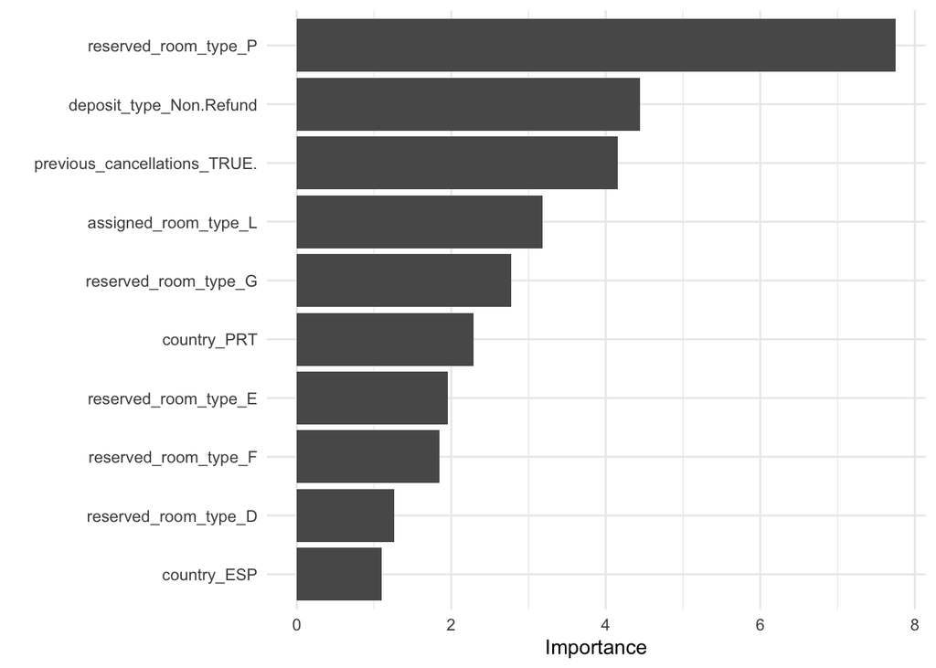

```r
hotels_lasso_final_mod %>%
  pull_workflow_fit() %>%
  vip()
```

**Use the last_fit() function to fit the final model and then apply it to the testing data. Report the metrics from the testing data using the collet_metrics() function. How do they compare to the cross-validated metrics?**

These metrics are only slightly higher than the cross-validated metrics.

```r
hotels_lasso_test <- hotels_lasso_final_wf %>%
  last_fit(hotels_split)
hotels_lasso_test %>%
  collect_metrics()
```

```
## # A tibble: 2 x 4
##   .metric  .estimator .estimate .config
##   <chr>    <chr>          <dbl> <fct>
## 1 accuracy binary         0.815 Preprocessor1_Model1
## 2 roc_auc  binary         0.894 Preprocessor1_Model1
```

**Use the collect_predictions() function to find the predicted probabilities and classes for the test data. Save this to a new dataset called preds. Then, use the conf_mat() function from dials (part of tidymodels) to create a confusion matrix showing the predicted classes vs. the true classes. What is the true positive rate (sensitivity)? What is the true negative rate (specificity)? See this Wikipedia reference if you (like me) tend to forget these definitions.**

```r
preds <- hotels_lasso_test %>%
  collect_predictions()
preds %>%
  conf_mat(.pred_class, is_canceled)
```

```
##           Truth
## Prediction     0     1
##          0 34291  3292
##          1  7747 14363
```

**Use the preds dataset you just created to create a density plot of the predicted probabilities of canceling (the variable is called .pred_1), filling by is_canceled. Use an alpha = .5 and color = NA in the geom_density(). Answer these questions:**

**a. What would this graph look like for a model with an accuracy that was close to 1?**

If the model had an accuracy of close to 1, then the graph would be able to distinguish between outcomes more accurately, leading to higher magnitudes for the density plots on each end of the spectrum.

**b. Our predictions are classified as canceled if their predicted probability of canceling is greater than .5. If we wanted to have a high true positive rate, should we make the cutoff for predicted as canceled higher or lower than .5?**

If we wanted to have a higher true positive rate, then we should make the cutoff for being predicted as canceled lower than .5 to ensure that any fringe/border cases will be considered as potential cancellations (assuming that we do not care about the decrease in specificity that this change would accompany)

**c. What happens to the true negative rate if we try to get a higher true positive rate?**

If we try to get a higher true positive rate without changing the actual accuracy of the model’s probability predictions, the true negative rate will decrease.

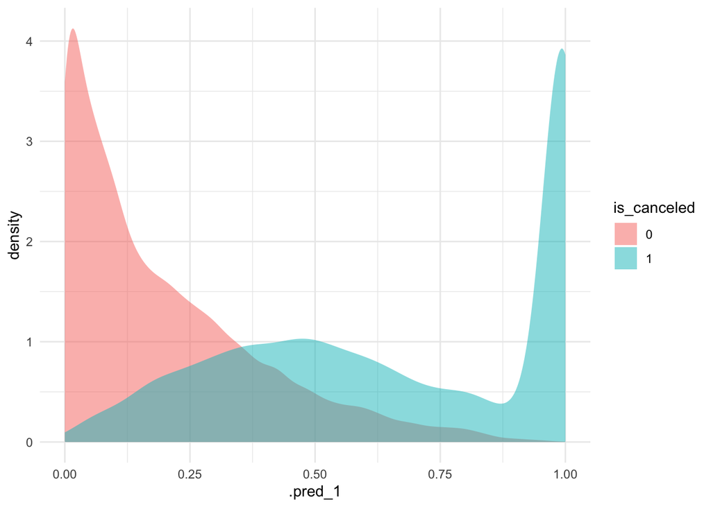

```r
preds %>%
  ggplot(aes(x = .pred_1, fill = is_canceled))+
  geom_density(alpha = 0.5, color = NA)
```

**8. Let’s say that this model is going to be applied to bookings 14 days in advance of their arrival at each hotel, and someone who works for the hotel will make a phone call to the person who made the booking. During this phone call, they will try to assure that the person will be keeping their reservation or that they will be canceling in which case they can do that now and still have time to fill the room. How should the hotel go about deciding who to call? How could they measure whether it was worth the effort to do the calling? Can you think of another way they might use the model?**

The hotel should likely decide to call customers who are at the highest risk of cancellation/may be border cases. The hotel may be able to safely assume that many of the low probability cancellations will honor their reservations and could possibly overbook in aniticipation of the high probability cancellations retracting their reservations, but the fringe cases of middling cancellation probability could be distinguishing. They could measure the effectiveness of this initiative by creating an economic profit model and monitoring the expected profits based on the model’s predictions, compared to the resulting profits after trying to force the customer’s hands (opened rooms from these canceled reservations that ultimately are filled by customers who are at a low-risk of cancelation should be beneficial towards the hotel’s profit projections).

**9. How might you go about questioning and evaluating the model in terms of fairness? Are there any questions you would like to ask of the people who collected the data?**

I would evaluate the fairness of the model by evaluating the demographics of the customers. I believe that this dataset has an extremely high likelihood of possessing ommitted variable biases, such as the credit scores of the customers, and given that there are not an overwhelmingly large number of unique consumers in this dataset compared to the population who engage in hotel bookings, I would be concerned about the external validity of the findings from this dataset. Once again, I would want to ask the researchers who collected this data about the customer consent and privacy considerations in this collection because some of this data seems like it should be kept private, although unique customer and reservation identification information could also be useful. Lastly, information about the specific hotels and their quality could have also been helpful, as some hotels may have been of lower quality, thus leading to an inherently higher probability of a reservation being canceled, to begin with.

# Exercise 4

## Reflection

I thought that Dr. Rachel Thomas’ Bias and Fairness lecture brought about discussion of many issues, some which were concepts that I had yet to think about regarding data ethics. I always think about the ethical and moral considerations of the work that I do when creating models and brainstorming their potential applications, but had yet to fully grasp the concept of evaluation bias and the potentially detrimental effects that it can have on societal equality. I was unsurpised by the decision of representation bias and the recommended correction method of merely creating training samples that are more representative of the total population in a variety of characteristics (the population that it will be applied to, at least). It is important that we pay attention to bias and fairness when studying data science because data scientists are afforded a certain degree of customization in the sculpting/wrangling of a dataset, and these decisions could ultimately have real-world consequences if they bias the findings of a research study and do not equally account for all demographics within the population. I had never heard of Evaluation Bias before, which Dr. Thomas describes biases in benchmark datasets are replicated at scale. The video discusses that this specific type of bias is often present in facial recognition datasets that include a disproportionate frequency of light-skinned men, compared to the actual population.